# Shotgun metagenomics processing and analysis 2025 - Statistical analysis

Edoardo Pasolli & Michele Avagliano

2025-Nov-28

## Install packages

- Here we install the third-party packages that we need

```r
install_if_missing <- function(packages, from = "cran"){
  if(!from %in% c("cran", "bioconductor")){
    stop("Unknown from source: use 'cran' or 'bioconductor'.")
  }

  installed_packages <- as.data.frame(installed.packages())$Package

  for(package in packages){
    if(!package %in% installed_packages){
      if(from == "cran"){
        install.packages(package, repos="https://cloud.r-project.org")
      } else if(from == "bioconductor"){
          if(!"BiocManager" %in% installed_packages){
            install.packages("BiocManager", repos="https://cloud.r-project.org")
          }
        BiocManager::install(package, ask = FALSE)
      }
    }
  }

}

bioconductor_packages <- c("curatedMetagenomicData", "ComplexHeatmap")

cran_packages <- c(
  "vegan", "dplyr", "ggplot2", "ggpubr", "tidyr", "tibble",
  "stringr", "circlize", "rstatix", "caret", "pROC"
)

install_if_missing(bioconductor_packages, from = "bioconductor")
install_if_missing(cran_packages, from = "cran")
```

## Import libraries

- Before using R packages, it is essential to load them in the R session using the library() function. This is necessary for importing and utilizing any package in R.
- The curatedMetagenomicData package in R provides a collection of curated metagenomic datasets, enabling researchers to access, analyze, and visualize data from a wide range of microbiome studies. It offers standardized metadata and taxonomy information, facilitating reproducibility and comparison across different studies. The package includes tools for loading datasets, conducting exploratory data analysis, and integrating metagenomic data with other biological data sources. By using curatedMetagenomicData, researchers can streamline their workflows and focus on biological insights rather than data management.

```r
library(curatedMetagenomicData)
```

## List datasets with relative abundance profiles available in curatedMetagenomicData

- The command curatedMetagenomicData(“relative_abundance”) is used to retrieve a curated dataset of relative abundance profiles from the package. This function allows users to access specific metagenomic data, focusing on relative abundances of taxa across various samples. By specifying “relative_abundance”, you can easily obtain a dataset that is ready for analysis, ensuring that the data is standardized and curated for accuracy.

```r
curatedMetagenomicData("relative_abundance")
```

```
## 2021-03-31.AsnicarF_2017.relative_abundance
## 2021-10-14.AsnicarF_2017.relative_abundance
## 2021-03-31.AsnicarF_2021.relative_abundance
## 2021-03-31.BackhedF_2015.relative_abundance
## 2021-10-14.BackhedF_2015.relative_abundance
## 2022-10-19.BedarfJR_2017.relative_abundance
## 2021-03-31.Bengtsson-PalmeJ_2015.relative_abundance
## 2021-10-14.Bengtsson-PalmeJ_2015.relative_abundance
## 2021-03-31.BritoIL_2016.relative_abundance
## 2021-03-31.BrooksB_2017.relative_abundance
## 2021-10-14.BrooksB_2017.relative_abundance
## 2021-03-31.Castro-NallarE_2015.relative_abundance
## 2021-03-31.ChengpingW_2017.relative_abundance
## 2021-10-14.ChengpingW_2017.relative_abundance
## 2021-03-31.ChngKR_2016.relative_abundance
## 2021-04-02.ChuDM_2017.relative_abundance
## 2021-03-31.CosteaPI_2017.relative_abundance
## 2021-10-14.CosteaPI_2017.relative_abundance
## 2021-03-31.DavidLA_2015.relative_abundance
## 2021-03-31.DeFilippisF_2019.relative_abundance
## 2021-03-31.DhakanDB_2019.relative_abundance
## 2021-03-31.FengQ_2015.relative_abundance
## 2021-03-31.FerrettiP_2018.relative_abundance
## 2022-04-13.FrankelAE_2017.relative_abundance
## 2021-03-31.GhensiP_2019.relative_abundance
## 2021-03-31.GopalakrishnanV_2018.relative_abundance
## 2021-10-14.GopalakrishnanV_2018.relative_abundance
## 2021-03-31.GuptaA_2019.relative_abundance
## 2021-03-31.HallAB_2017.relative_abundance
## 2021-10-14.HallAB_2017.relative_abundance
## 2021-03-31.HanniganGD_2017.relative_abundance
## 2021-03-31.HansenLBS_2018.relative_abundance
## 2021-10-14.HansenLBS_2018.relative_abundance
## 2021-03-31.Heitz-BuschartA_2016.relative_abundance
## 2021-03-31.HMP_2012.relative_abundance
## 2021-03-31.HMP_2019_ibdmdb.relative_abundance
## 2021-10-14.HMP_2019_ibdmdb.relative_abundance
## 2021-03-31.HMP_2019_t2d.relative_abundance
## 2022-10-19.IaniroG_2022.relative_abundance
## 2021-03-31.IjazUZ_2017.relative_abundance
```

[output cut: 67 more lines]

```
## 2021-03-31.VincentC_2016.relative_abundance
## 2021-03-31.VogtmannE_2016.relative_abundance
## 2021-03-31.WampachL_2018.relative_abundance
## 2022-04-13.WindTT_2020.relative_abundance
## 2021-03-31.WirbelJ_2018.relative_abundance
## 2021-03-31.XieH_2016.relative_abundance
## 2021-03-31.YachidaS_2019.relative_abundance
## 2021-10-14.YachidaS_2019.relative_abundance
## 2021-03-31.YassourM_2016.relative_abundance
## 2021-03-31.YassourM_2018.relative_abundance
## 2021-03-31.YeZ_2018.relative_abundance
## 2021-03-31.YuJ_2015.relative_abundance
## 2021-03-31.ZeeviD_2015.relative_abundance
## 2021-03-31.ZellerG_2014.relative_abundance
## 2021-03-31.ZhuF_2020.relative_abundance
```

## Select the “ZellerG_2014” dataset

- Metagenomic data from the curated dataset “ZellerG_2014” are retrieved from the curatedMetagenomicData package.
- It retrieves relative abundance data and associated metadata from the study and saves them as tabular files for further analysis.

```r
# Load the data for the specified study (ZellerG_2014) with relative abundance values.
# The 'dryrun' parameter is set to FALSE to execute the retrieval, and 'rownames' is set to "long" for row naming.
data <- curatedMetagenomicData("ZellerG_2014.relative_abundance", dryrun = FALSE, rownames = "long")
```

```
##
## $`2021-03-31.ZellerG_2014.relative_abundance`
## dropping rows without rowTree matches:
##   k__Bacteria|p__Actinobacteria|c__Coriobacteriia|o__Coriobacteriales|f__Atopobiaceae|g__Olsenella|s__Olsenella_profusa
##   k__Bacteria|p__Actinobacteria|c__Coriobacteriia|o__Coriobacteriales|f__Coriobacteriaceae|g__Collinsella|s__Collinsella_stercoris
##   k__Bacteria|p__Actinobacteria|c__Coriobacteriia|o__Coriobacteriales|f__Coriobacteriaceae|g__Enorma|s__[Collinsella]_massiliensis
##   k__Bacteria|p__Firmicutes|c__Bacilli|o__Bacillales|f__Bacillales_unclassified|g__Gemella|s__Gemella_bergeri
##   k__Bacteria|p__Firmicutes|c__Bacilli|o__Lactobacillales|f__Carnobacteriaceae|g__Granulicatella|s__Granulicatella_elegans
##   k__Bacteria|p__Firmicutes|c__Clostridia|o__Clostridiales|f__Ruminococcaceae|g__Ruminococcus|s__Ruminococcus_champanellensis
##   k__Bacteria|p__Firmicutes|c__Erysipelotrichia|o__Erysipelotrichales|f__Erysipelotrichaceae|g__Bulleidia|s__Bulleidia_extructa
##   k__Bacteria|p__Proteobacteria|c__Betaproteobacteria|o__Burkholderiales|f__Sutterellaceae|g__Sutterella|s__Sutterella_parvirubra
##   k__Bacteria|p__Synergistetes|c__Synergistia|o__Synergistales|f__Synergistaceae|g__Cloacibacillus|s__Cloacibacillus_evryensis
```

```r
# Extract the first element of the retrieved data (a SummarizedExperiment object) and access the relative abundance values.
abundance_data <- assay(data[[1]])

# Convert the relative abundance matrix to a data frame for easier manipulation and analysis.
abundance_df <- as.data.frame(abundance_data)

# Save the relative abundance data frame to a tabular file named "relative_abundances.tsv" with tab separation.
# 'row.names = TRUE' includes the row names in the output file.
write.table(abundance_df, "relative_abundances.tsv", sep = "\t", row.names = TRUE, col.names = NA)

# Extract the metadata associated with the samples from the SummarizedExperiment object.
metadata <- colData(data[[1]])

# Convert the metadata to a data frame (if needed) for easier manipulation and analysis.
metadata_df <- as.data.frame(metadata)

# Save the metadata data frame to a tabular file named "metadata.tsv" with tab separation.
# 'row.names = TRUE' includes the row names in the output file.
write.table(metadata_df, "metadata.tsv", sep  = "\t", row.names = TRUE, col.names = NA)
```

## Read again the “ZellerG_2014” dataset from files

- After clearing the R environment, relative abundance and metadata can be read through the tab-delimited files into data frames. The data frames can be merged by sample identifiers, resulting in a unified data frame ready for analysis.

```r
# Clear the R environment by removing all existing objects from the workspace.
rm(list = ls())

# Read the relative abundance data from the tabular file "relative_abundances.tsv" into a data frame.
# 'sep = "\t"' specifies tab as the delimiter, 'header = TRUE' indicates that the first row contains column names,
# 'row.names = 1' sets the first column as the row names, and 'check.names = FALSE' prevents R from modifying column names.
abundance_df <- read.table("relative_abundances.tsv", sep = "\t", header = TRUE, row.names = 1, check.names = FALSE)

# Read the metadata from the tabular file "metadata.tsv" into a data frame with the same parameters as above.
metadata_df <- read.table("metadata.tsv", sep = "\t", header = TRUE, row.names = 1, check.names = FALSE)

# Transpose the abundance data frame so that samples become rows and taxa become columns.
abundance_df <- as.data.frame(t(abundance_df))

# Store the column names of the abundance data frame (taxa) and the metadata data frame.
taxa <- colnames(abundance_df)
meta <- colnames(metadata_df)

# Merge the metadata and abundance data frames by row names (sample identifiers).
df <- merge(metadata_df, abundance_df, by = "row.names")

# Set the row names of the merged data frame to the original row names column (sample identifiers).
# Remove the additional Row.names column created during the merge.
row.names(df) <- df$Row.names
df$Row.names <- NULL
```

## Alpha diversity analysis: computing indices

- Alpha diversity assess the diversity within individual samples.
- The three common alpha diversity indices: Shannon, Simpson, and Richness.
- Here, we use the vegan package that provides functions for diversity analysis, such as calculating species richness and evenness.

```r
# Load the necessary libraries
library(vegan)
library(dplyr)
# Calculate alpha diversity (Shannon, Simpson, or Richness) for each sample
# Shannon diversity index
shannon_div <- diversity(select(df, all_of(taxa)), index = "shannon")

# Simpson diversity index
simpson_div <- diversity(select(df, all_of(taxa)), index = "simpson")

# Richness (total number of taxa present in each sample)
richness <- rowSums(select(df, all_of(taxa)) > 0)

# Create a data frame to combine the diversity indices
alpha_diversity_df <- data.frame(
  Shannon = shannon_div,
  Simpson = simpson_div,
  Richness = richness
)
```

## Alpha diversity analysis: do boxplots (comparison for variable “study_condition”)

- We want to compare alpha diversity among different study conditions
- We use a graphical representation based on boxplots

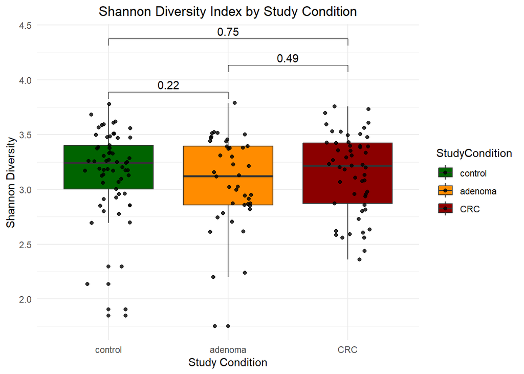

```r
# Load necessary libraries
library(ggplot2)
library(ggpubr)

# Add variable "study_condition" to the dataframe
alpha_diversity_df$StudyCondition <- df$study_condition

# Set the order of StudyCondition factor
alpha_diversity_df$StudyCondition <- factor(alpha_diversity_df$StudyCondition, levels = c("control", "adenoma", "CRC"))

# Define color palette
colors <- c("control" = "darkgreen", "adenoma" = "darkorange", "CRC" = "darkred")

# Define the pairwise comparisons
comparisons <- list(c("control", "adenoma"), c("adenoma", "CRC"), c("control", "CRC"))

# Generate boxplots for each diversity index with p-values
# Shannon diversity boxplot with p-value
ggplot(alpha_diversity_df, aes(x = StudyCondition, y = Shannon, fill = StudyCondition)) +
  geom_boxplot() +
  geom_jitter(width = 0.2, size = 1.5, alpha = 0.8) +  # Add individual points with jitter
  labs(title = "Shannon Diversity Index by Study Condition", x = "Study Condition", y = "Shannon Diversity") +
  theme_minimal() +
  theme(plot.title = element_text(hjust = 0.5)) +  # Center the title
  stat_compare_means(comparisons = comparisons, method = "wilcox.test", label = "p.format", label.x.npc = "center") +  # Add pairwise p-values
  scale_fill_manual(values = colors)
```

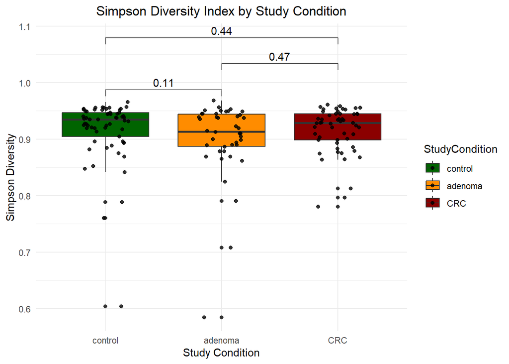

```r
# Simpson diversity boxplot with p-value
ggplot(alpha_diversity_df, aes(x = StudyCondition, y = Simpson, fill = StudyCondition)) +
  geom_boxplot() +
  geom_jitter(width = 0.2, size = 1.5, alpha = 0.8) +  # Add individual points with jitter
  labs(title = "Simpson Diversity Index by Study Condition", x = "Study Condition", y = "Simpson Diversity") +
  theme_minimal() +
  theme(plot.title = element_text(hjust = 0.5)) +  # Center the title
  stat_compare_means(comparisons = comparisons, method = "wilcox.test", label = "p.format", label.x.npc = "center") +  # Add pairwise p-values
  scale_fill_manual(values = colors)
```

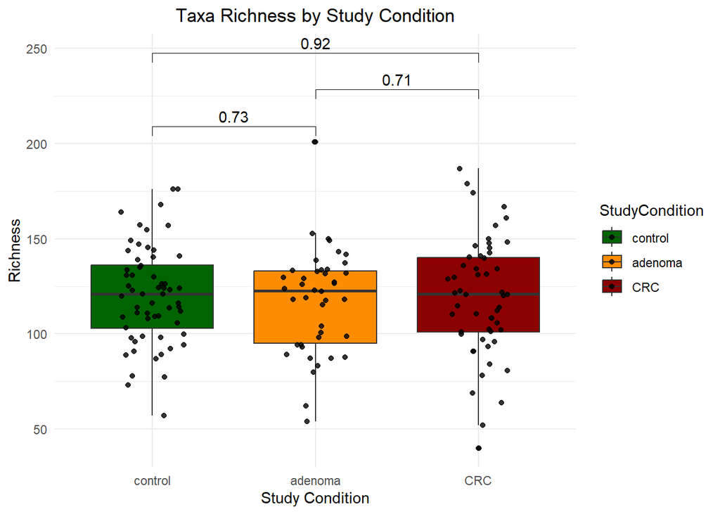

```r
# Richness boxplot with p-value
ggplot(alpha_diversity_df, aes(x = StudyCondition, y = Richness, fill = StudyCondition)) +
  geom_boxplot() +
  geom_jitter(width = 0.2, size = 1.5, alpha = 0.8) +  # Add individual points with jitter
  labs(title = "Taxa Richness by Study Condition", x = "Study Condition", y = "Richness") +
  theme_minimal() +
  theme(plot.title = element_text(hjust = 0.5)) +  # Center the title
  stat_compare_means(comparisons = comparisons, method = "wilcox.test", label = "p.format", label.x.npc = "center") +  # Add pairwise p-values
  scale_fill_manual(values = colors)
```

## Beta diversity analysis

- Beta diversity analysis helps researchers understand whether different sample groups (e.g., control, adenoma, CRC) have distinct microbial communities
- Significant differences in beta diversity between groups suggest that microbial community composition is influenced by the variable of interest, such as a disease state or treatment condition. Conversely, a lack of significant differences might suggest that the microbial communities are relatively similar across conditions.

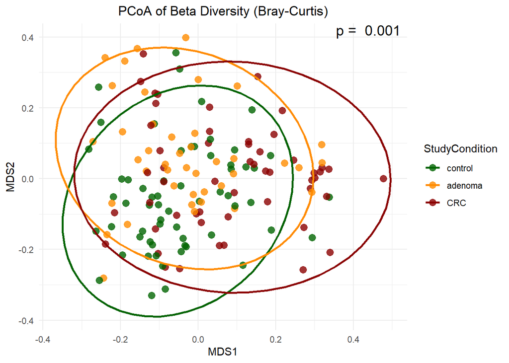

```r
# Beta diversity analysis: Bray-Curtis distance calculation
beta_dist <- vegdist(select(df, all_of(taxa)), method = "bray")

# PCoA analysis
pcoa_results <- cmdscale(beta_dist, eig = TRUE, k = 2)  # Perform PCoA with 2 components
pcoa_df <- data.frame(
  MDS1 = pcoa_results$points[, 1],
  MDS2 = pcoa_results$points[, 2],
  StudyCondition = df$study_condition  # Add study_condition for coloring
)

# Set the order of StudyCondition factor
pcoa_df$StudyCondition <- factor(pcoa_df$StudyCondition, levels = c("control", "adenoma", "CRC"))

# Define color palette
colors <- c("control" = "darkgreen", "adenoma" = "darkorange", "CRC" = "darkred")

# Perform PERMANOVA (adonis2) to compare groups based on Bray-Curtis distance
adonis_results <- adonis2(beta_dist ~ df$study_condition, permutations = 999)

# PCoA plot with jittered points and p-value
ggplot(pcoa_df, aes(x = MDS1, y = MDS2, color = StudyCondition)) +
  geom_point(size = 3, alpha = 0.8) +  # Add points with opacity
  scale_color_manual(values = colors) +
  stat_ellipse(aes(group = StudyCondition), level = 0.95, type = "t", size = 1) +  # Add ellipses
  labs(title = "PCoA of Beta Diversity (Bray-Curtis)", x = "MDS1", y = "MDS2") +
  theme_minimal() +
  theme(plot.title = element_text(hjust = 0.5)) +  # Center the title
  annotate("text", x = Inf, y = Inf, label = paste("p = ", round(adonis_results$`Pr(>F)`[1], 3)),
           hjust = 1.1, vjust = 1.1, size = 5, color = "black")  # Add p-value from PERMANOVA
```

```r
# NMDS analysis using Bray-Curtis distance
nmds_results <- metaMDS(select(df, all_of(taxa)), distance = "bray", k = 2, trymax = 100)  # Perform NMDS
```

```
## Square root transformation
## Wisconsin double standardization
## *** Best solution was not repeated -- monoMDS stopping criteria:
##     46: no. of iterations >= maxit
##     54: stress ratio > sratmax
```

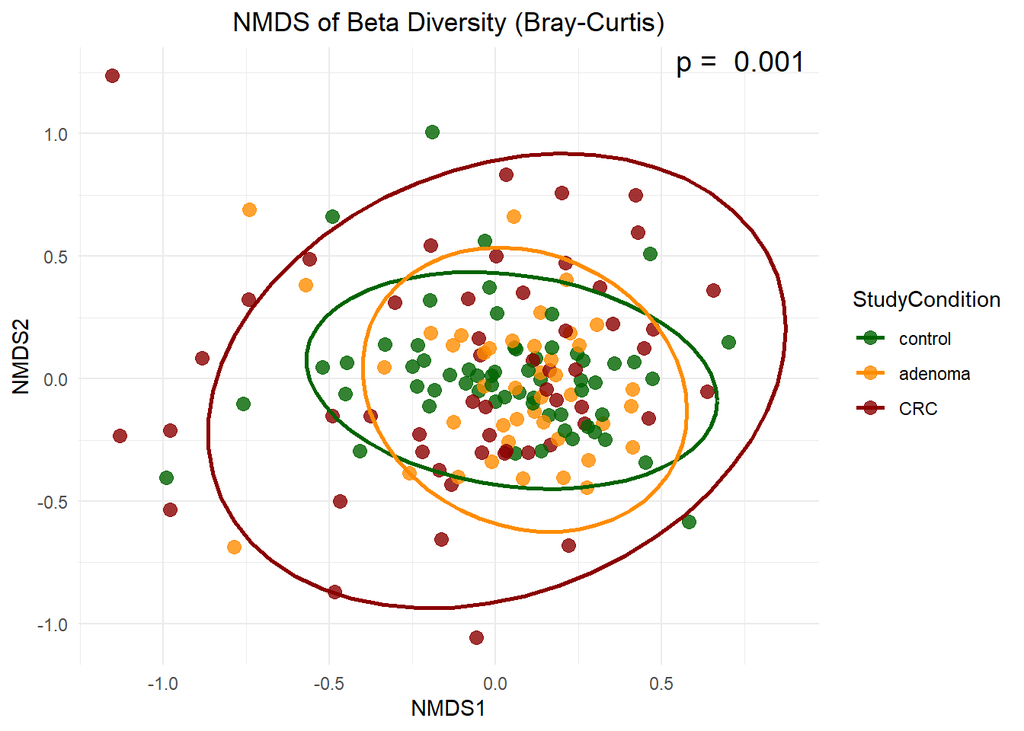

```r
nmds_df <- data.frame(
  NMDS1 = nmds_results$points[, 1],
  NMDS2 = nmds_results$points[, 2],
  StudyCondition = df$study_condition
)

# Set the order of StudyCondition factor
nmds_df$StudyCondition <- factor(nmds_df$StudyCondition, levels = c("control", "adenoma", "CRC"))

# NMDS plot with jittered points and p-value
ggplot(nmds_df, aes(x = NMDS1, y = NMDS2, color = StudyCondition)) +
  geom_point(size = 3, alpha = 0.8) +  # Add points with opacity
  scale_color_manual(values = colors) +
  stat_ellipse(aes(group = StudyCondition), level = 0.95, type = "t", size = 1) +  # Add ellipses
  labs(title = "NMDS of Beta Diversity (Bray-Curtis)", x = "NMDS1", y = "NMDS2") +
  theme_minimal() +
  theme(plot.title = element_text(hjust = 0.5)) +  # Center the title
  annotate("text", x = Inf, y = Inf, label = paste("p = ", round(adonis_results$`Pr(>F)`[1], 3)),
           hjust = 1.1, vjust = 1.1, size = 5, color = "black")  # Add p-value from PERMANOVA
```

```r
# Load necessary libraries
library(tidyr)
library(tibble)
library(stringr)

# Create a long-format dataframe where 'taxa' columns are stacked into one column
df_long <- df %>%
  select(all_of(taxa)) %>%  # Select only the columns related to taxa
  rownames_to_column("Sample") %>%  # To keep sample names as a column
  pivot_longer(cols = -Sample,  # Reshape from wide to long (keeping 'Sample' as identifier)
               names_to = "Taxa",  # Column name for the taxa
               values_to = "RelativeAbundance")  # Column name for the values (relative abundances)

df_long$Phylum <- str_extract(df_long$Taxa, "(?<=\\|p__)[^|]+")

# Summarize the data at the sample level for the grouped phyla
df_summary <- df_long %>%
  group_by(Sample, Phylum) %>%
  summarise(CumulativeRelativeAbundance = sum(RelativeAbundance)) %>%
  ungroup()
# Calculate the overall abundance of each phylum
phylum_abundance <- df_summary %>%
  group_by(Phylum) %>%
  summarise(TotalAbundance = sum(CumulativeRelativeAbundance)) %>%
  arrange(desc(TotalAbundance))

# Identify the 7 most prevalent phyla
top_phyla <- phylum_abundance$Phylum[1:7]

# Modify df_summary to keep only the top 7 most prevalent phyla, grouping others as "Other"
df_summary <- df_summary %>%
  mutate(Phylum = ifelse(Phylum %in% top_phyla, Phylum, "Other"))

# Set "Other" as the last factor level in Phylum
df_summary$Phylum <- factor(df_summary$Phylum, levels = c(top_phyla, "Other"))

# Re-summarize to account for the "Other" category
df_summary <- df_summary %>%
  group_by(Sample, Phylum) %>%
  summarise(CumulativeRelativeAbundance = sum(CumulativeRelativeAbundance)) %>%
  ungroup()
```

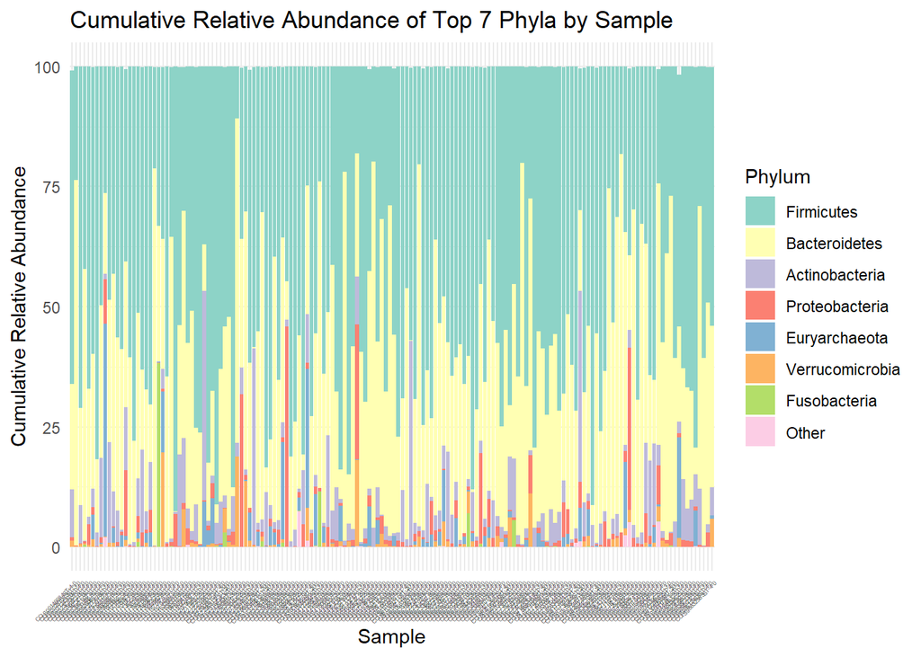

```r
# Create the bar plot with samples on the x-axis and cumulative relative abundances on the y-axis
ggplot(df_summary, aes(x = Sample, y = CumulativeRelativeAbundance, fill = Phylum)) +
  geom_bar(stat = "identity", position = "stack") +  # Stacked bar plot
  labs(title = "Cumulative Relative Abundance of Top 7 Phyla by Sample", x = "Sample", y = "Cumulative Relative Abundance") +
  theme_minimal() +
  theme(axis.text.x = element_text(angle = 45, hjust = 1, size = 3)) +  # Rotate x-axis labels
  scale_fill_brewer(palette = "Set3")  # Set color palette
```

## (Phylum) composition of microbial communities across study conditions

- We can do the same thing by grouping for “study_condition”

```r
# Create a long-format dataframe where 'taxa' columns are stacked into one column
df_long <- df %>%
  select(all_of(c("study_condition", taxa))) %>%  # Include 'study_condition' in the selection
  rownames_to_column("Sample") %>%  # To keep sample names as a column
  pivot_longer(cols = -c(Sample, study_condition),  # Reshape from wide to long (keeping 'Sample' and 'study_condition' as identifiers)
               names_to = "Taxa",  # Column name for the taxa
               values_to = "RelativeAbundance")  # Column name for the values (relative abundances)

# Extract the phylum level from the 'Taxa' column
df_long$Phylum <- str_extract(df_long$Taxa, "(?<=\\|p__)[^|]+")

# Summarize the data at the study_condition level for the grouped phyla
df_summary <- df_long %>%
  group_by(study_condition, Phylum) %>%
  summarise(CumulativeRelativeAbundance = sum(RelativeAbundance)) %>%
  ungroup()
# Calculate the overall abundance of each phylum
phylum_abundance <- df_summary %>%
  group_by(Phylum) %>%
  summarise(TotalAbundance = sum(CumulativeRelativeAbundance)) %>%
  arrange(desc(TotalAbundance))

# Identify the top 7 most prevalent phyla
top_phyla <- phylum_abundance$Phylum[1:7]

# Modify df_summary to keep only the top 7 most prevalent phyla, grouping others as "Other"
df_summary <- df_summary %>%
  mutate(Phylum = ifelse(Phylum %in% top_phyla, Phylum, "Other"))

# Set "Other" as the last factor level in Phylum
df_summary$Phylum <- factor(df_summary$Phylum, levels = c(top_phyla, "Other"))

# Re-summarize to account for the "Other" category
df_summary <- df_summary %>%
  group_by(study_condition, Phylum) %>%
  summarise(CumulativeRelativeAbundance = sum(CumulativeRelativeAbundance)) %>%
  ungroup()
```

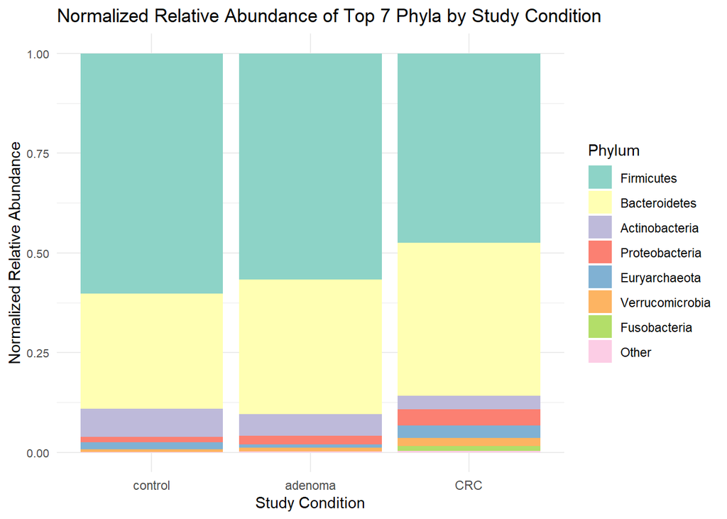

```r
# Normalize cumulative relative abundances within each study_condition
df_summary <- df_summary %>%
  group_by(study_condition) %>%
  mutate(NormalizedAbundance = CumulativeRelativeAbundance / sum(CumulativeRelativeAbundance)) %>%
  ungroup()

# Set factor levels for study_condition to ensure the correct order
df_summary$study_condition <- factor(df_summary$study_condition, levels = c("control", "adenoma", "CRC"))

# Create the bar plot with study_condition on the y-axis, normalized abundances
ggplot(df_summary, aes(x = study_condition, y = NormalizedAbundance, fill = Phylum)) +
  geom_bar(stat = "identity", position = "stack") +  # Stacked bar plot
  labs(title = "Normalized Relative Abundance of Top 7 Phyla by Study Condition", x = "Study Condition", y = "Normalized Relative Abundance") +
  theme_minimal() +
  theme(axis.text.y = element_text(size = 8, angle = 0, hjust = 1)) +  # Smaller text for y-axis labels
  scale_fill_brewer(palette = "Set3")  # Set color palette
```

## Heatmap for the 30 most abundant species

- Let’s do an heatmap that report the 30 most abundant species in our set of samples

[figure not shown]

```r
# Load necessary libraries
library(ComplexHeatmap)
library(circlize)
# Compute the total relative abundance for each taxa
sum_taxa <- df %>% select(all_of(taxa)) %>% colSums()

# Select the 30 taxa with the highest sum values
top_30_taxa <- names(sort(sum_taxa, decreasing = TRUE))[1:30]

# Subset the dataframe to include only the top 30 columns
df_top_30 <- df %>% select(all_of(top_30_taxa))

# Apply log10 transformation (add 0.00001 to avoid log(0) issues)
df_top_30_log <- log10(df_top_30 + 0.00001)  # Adding 0.00001 to avoid taking log of 0

# Create a heatmap matrix
df_top_30_log <- as.matrix(df_top_30_log) # Convert the dataframe to matrix for heatmap
colnames(df_top_30_log) <- str_extract(colnames(df_top_30_log), "(?<=\\|s__)[^|]+") # Extract species names from the column names (assuming species is after 's__')

# Create a sample annotation for study_condition
study_condition_annotation <- rowAnnotation(
  condition = df$study_condition,
  col = list(condition = c("control" = "darkgreen", "adenoma" = "darkorange", "CRC" = "darkred"))
)

Heatmap(df_top_30_log,
        name = "Log10(Relative Abundance)",  # Heatmap color legend title
        column_title = "Species",  # Title for columns
        row_title = "Samples",  # Title for rows
        show_row_names = FALSE,  # Show row names
        show_column_names = TRUE,  # Show column names
        cluster_rows = TRUE,  # Cluster rows
        cluster_columns = TRUE,  # Cluster columns
        col = colorRamp2(c(-4, -2, 0, 1), c("darkblue", "white", "red", "yellow")),  # Color scale
        heatmap_legend_param = list(title = "Log10(Relative Abundance)", legend_width = unit(4, "cm")),
        column_names_gp = gpar(fontface = "italic"),  # Italicize column names
        left_annotation = study_condition_annotation)  # Add study_condition annotation to the left of the heatmap
```

## Correlation analysis: computation

- Correlation analysis is important to identify relationships between variables.
- In microbiome studies, it helps reveal associations between microbial taxa and host factors (e.g., BMI, disease status, diet, etc).
- By identifying which taxa are positively or negatively correlated with specific variables, it is possible to uncover patterns that suggest potential roles of certain microbes in health or disease. For instance, a strong correlation between a taxon and BMI may indicate a microbial role in metabolism, which could be further investigated for therapeutic insights.
- Correlation is different from causation: Correlation analysis is a first step in understanding the complex interplay between the microbiome and its host, guiding researchers toward more detailed mechanistic studies.
- Let’s compute the correlation between taxa and BMI

```r
# Ensure that the BMI variable is numeric
df$BMI <- as.numeric(df$BMI)

# Calculate the presence of each taxon in at least 5% of the samples
min_samples <- 0.05 * nrow(df)  # 5% of the total number of samples
present_taxa <- colSums(df[taxa]) > min_samples  # Identify taxa present in at least 5% of the samples

# Filter taxa to only include those that meet the presence threshold
taxa_filtered <- taxa[present_taxa]

# Initialize vectors to store the taxa names, correlation coefficients, and p-values
taxa_names <- character(length(taxa_filtered))
correlations <- numeric(length(taxa_filtered))
p_values <- numeric(length(taxa_filtered))

# Loop through each filtered taxon and compute the correlation with BMI using Spearman correlation
for (i in seq_along(taxa_filtered)) {
  taxon <- taxa_filtered[i]

  # Perform the Spearman correlation test between the taxon and BMI
  cor_test <- cor.test(df[[taxon]], df$BMI, method = "spearman")

  # Store the results in the respective vectors
  taxa_names[i] <- taxon
  correlations[i] <- cor_test$estimate
  p_values[i] <- cor_test$p.value
}

# Apply FDR correction to p-values
adjusted_p_values <- p.adjust(p_values, method = "fdr")

# Create a data frame to store the results with columns for taxa, correlation, p-value, and adjusted p-value
cor_df <- data.frame(
  Taxon = taxa_names,
  Correlation = correlations,
  P_value = p_values,
  Adjusted_P_value = adjusted_p_values
)
```

- False discovery rate (FDR) correction is extremely important in statistical analysis when performing multiple hypothesis tests.
- Each test has a probability of yielding a significant result purely by chance, which increases with the number of tests.
- For example, in microbiome studies, correlations between dozens or hundreds of taxa and a variable like BMI are calculated simultaneously. Without correction, even unrelated taxa could appear significantly correlated simply due to random chance.
- FDR correction addresses this by controlling the expected proportion of false positives (incorrectly significant results) among the set of tests deemed significant.
- Unlike stricter corrections like the Bonferroni method, FDR is often used in exploratory fields like genomics or microbiome research, where a balance between discovering true positives and limiting false positives is crucial.
- It allows researchers to draw more reliable conclusions from large-scale analyses, minimizing the risk of overinterpreting random results while maintaining sufficient power to detect genuine associations.

## Correlation analysis: barplot

- Let’s do a barplot with the top-20 correlations
- Correlations with adjusted p-value < 0.2 (we used a quite relaxed threshold!) are highlighted as significant

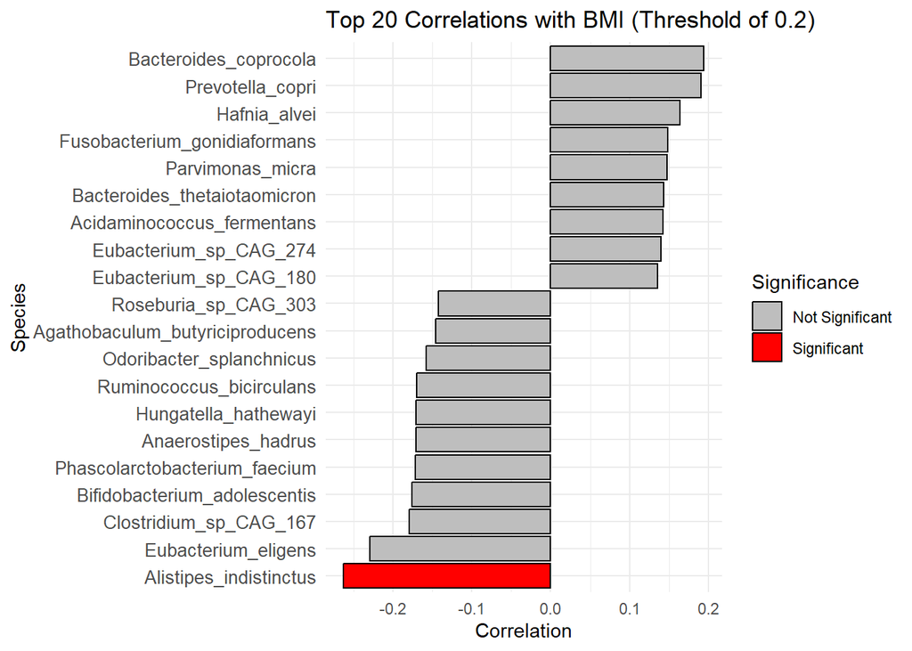

```r
# Order the data by absolute correlation values
cor_df$Abs_Correlation <- abs(cor_df$Correlation)

# Sort the data frame by absolute correlation values in descending order
cor_df_sorted <- cor_df[order(cor_df$Abs_Correlation, decreasing = TRUE), ]

# Select the top 20 correlations (both positive and negative)
top_20_correlations <- cor_df_sorted[1:20, ]

# Apply a threshold of 0.2 for significance based on adjusted p-value
top_20_correlations$Significance <- ifelse(top_20_correlations$Adjusted_P_value < 0.2, "Significant", "Not Significant")

# Extract species name after 's__'
top_20_correlations$Species <- sub(".*s__([^;]+)", "\\1", top_20_correlations$Taxon)

# Plot bar plot of the top 20 correlations, colored by significance
ggplot(top_20_correlations, aes(x = reorder(Species, Correlation), y = Correlation, fill = Significance)) +
  geom_bar(stat = "identity", color = "black") +
  coord_flip() +
  labs(title = "Top 20 Correlations with BMI (Threshold of 0.2)",
       x = "Species", y = "Correlation") +
  scale_fill_manual(values = c("Significant" = "red", "Not Significant" = "grey")) +
  theme_minimal() +
  theme(axis.text.y = element_text(size = 10))  # Adjust text size for readability
```

## Correlation analysis: scatterplot of Alistipes indistinctus and BMI

- Let’s do a scatterplot of Alistipes indistinctus and BMI

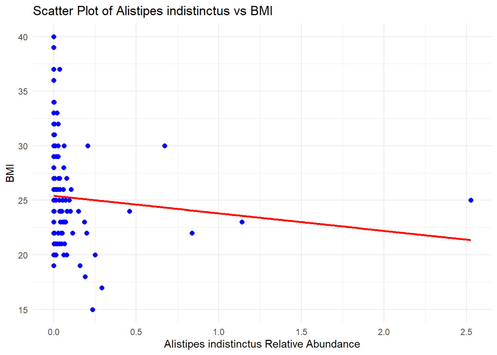

```r
# Extract the data for Alistipes_indistinctus (using partial matching) and BMI
alistipes_bmi <- data.frame(
  BMI = df$BMI,
  Alistipes_indistinctus = df[, grep("Alistipes_indistinctus", colnames(df))]
)

# Create the scatter plot
ggplot(alistipes_bmi, aes(x = Alistipes_indistinctus, y = BMI)) +
  geom_point(color = "blue", size = 2) +  # Scatter points
  geom_smooth(method = "lm", se = FALSE, color = "red") +  # Linear regression line
  labs(title = "Scatter Plot of Alistipes indistinctus vs BMI",
       x = "Alistipes indistinctus Relative Abundance",
       y = "BMI") +
  theme_minimal()
```

## Differential abundance analysis: the Wilcoxon rank-sum test

- Differential abundance analysis is a key statistical approach used to identify changes in the abundance of specific microbial taxa between different experimental groups or conditions.
- It helps in understanding how specific factors (e.g., disease, treatment, diet, environmental exposures) affect the microbiome composition.
- This analysis compares the relative abundance of taxa between groups to identify which ones are significantly different.
- It can provide insights into how shifts in microbial communities correlate with specific health outcomes or experimental conditions.
- Statistical testing: Various methods can be applied to compare the abundance of taxa across groups. Common methods include:
  - t-tests or ANOVA for normally distributed data.
  - Wilcoxon rank-sum test for non-parametric data or when the assumptions of normality are not met. The Wilcoxon rank-sum test compares the ranks of values between two independent groups, making it particularly useful when dealing with skewed or non-normally distributed abundance data.
  - Non-parametric tests like the Kruskal-Wallis test for comparing multiple groups.
  - More advanced techniques like generalized linear models or methods that account for compositional data.
- Multiple testing correction: Since many taxa are being tested simultaneously, corrections for multiple comparisons (e.g., FDR) are applied to control for type I errors.
- Interpretation: Significant changes in microbial abundance may provide insights into biological processes, potential biomarkers for disease, or targets for therapeutic interventions.

```r
# Load necessary libraries
library(rstatix)
# Filter samples by "study_condition" to include only "control" and "CRC"
filtered_df <- df[df$study_condition %in% c("control", "CRC"), ]

# Extract the abundance data (only taxa columns) and remove taxa that are zero across all samples
abundance_data <- filtered_df[, taxa]
non_zero_taxa <- colSums(abundance_data != 0) > 0
abundance_data <- abundance_data[, non_zero_taxa]

# Update the filtered data frame to include only the non-zero taxa
filtered_df <- cbind(filtered_df[, meta], abundance_data)

# Initialize vectors to store p-values, effect sizes, and direction
p_values <- c()
effect_sizes <- c()
directions <- c()

# Perform Wilcoxon rank-sum test, calculate effect size, and determine direction for each taxon
for (taxon in names(abundance_data)) {
  # Create a temporary data frame for the current taxon
  temp_df <- data.frame(
    Abundance = filtered_df[[taxon]],
    study_condition = filtered_df$study_condition
  )

  # Perform Wilcoxon rank-sum test
  test_result <- wilcox.test(Abundance ~ study_condition, data = temp_df)
  p_values[taxon] <- test_result$p.value

  # Calculate effect size for the current taxon using wilcox_effsize
  effect_size_result <- temp_df %>%
    wilcox_effsize(Abundance ~ study_condition)
  effect_sizes[taxon] <- effect_size_result$effsize

  # Determine the direction of enrichment by comparing group means
  mean_control <- mean(temp_df$Abundance[temp_df$study_condition == "control"])
  mean_crc <- mean(temp_df$Abundance[temp_df$study_condition == "CRC"])
  if (mean_crc > mean_control) {
    directions[taxon] <- "Enriched in CRC"
  } else if (mean_control > mean_crc) {
    directions[taxon] <- "Enriched in Control"
  } else {
    directions[taxon] <- "No Difference"
  }
}

# Adjust p-values for multiple testing to control for FDR
adjusted_p_values <- p.adjust(p_values, method = "fdr")

# Combine results into a data frame with all taxa, including effect sizes and direction
results <- data.frame(
  Taxon = names(adjusted_p_values),
  P_Value = p_values,
  Adjusted_P_Value = adjusted_p_values,
  Effect_Size = effect_sizes,
  Direction = directions
)
```

## Differential abundance analysis: barplot with most significant taxa

- Let’s do a barplot that reports the taxa with adjusted p-value < 0.2

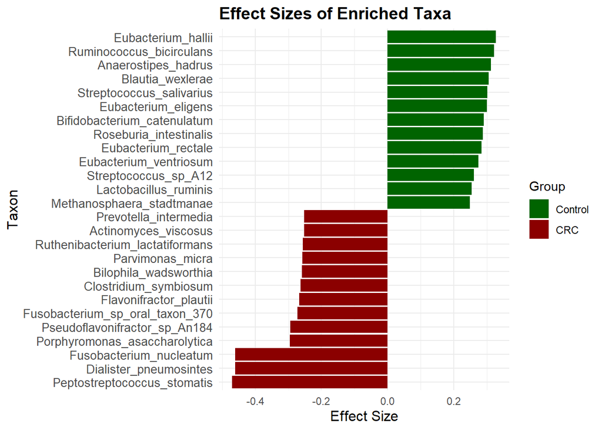

```r
# Extract the taxa names after "s__"
results$Taxon2 <- gsub(".*s__", "", results$Taxon)

# Filter the results for adjusted p-values < 0.2
filtered_results <- results[results$Adjusted_P_Value < 0.2, ]

# Extract the enriched taxa for Control and CRC groups
enriched_control <- filtered_results[filtered_results$Direction == "Enriched in Control", ]
enriched_crc <- filtered_results[filtered_results$Direction == "Enriched in CRC", ]

# Adjust the effect sizes for direction (positive for Control, negative for CRC)
enriched_control$Effect_Size <- abs(enriched_control$Effect_Size)  # Keep effect size positive for control
enriched_crc$Effect_Size <- -abs(enriched_crc$Effect_Size)  # Make effect size negative for CRC

# Prepare data for plotting
plot_data <- rbind(
  data.frame(Taxon = enriched_control$Taxon2,
             Effect_Size = enriched_control$Effect_Size,
             Group = "Control"),
  data.frame(Taxon = enriched_crc$Taxon2,
             Effect_Size = enriched_crc$Effect_Size,
             Group = "CRC")
)

# Plot the bar plot
ggplot(plot_data, aes(x = reorder(Taxon, Effect_Size), y = Effect_Size, fill = Group)) +
  geom_bar(stat = "identity") +
  coord_flip() +
  scale_fill_manual(values = c("Control" = "darkgreen", "CRC" = "darkred")) +
  labs(x = "Taxon", y = "Effect Size", title = "Effect Sizes of Enriched Taxa") +
  theme_minimal() +
  theme(axis.text.y = element_text(size = 10),
        axis.title = element_text(size = 12),
        plot.title = element_text(size = 14, face = "bold"))
```

## Differential abundance analysis: boxplot for Fusobacterium nucleatum

- Let’s do a boxplot for Fusobacterium nucleatum across “study_condition”

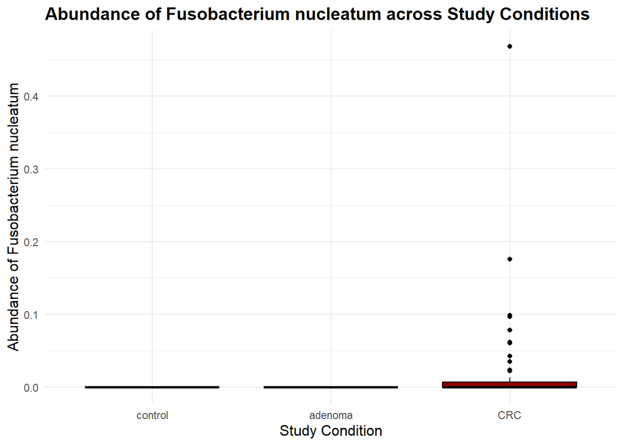

```r
# Extract the data for Fusobacterium_nucleatum (using partial matching) and study_condition
nucleatum_condition <- data.frame(
  study_condition = factor(df$study_condition, levels = c("control", "adenoma", "CRC")),  # Set the order of the levels
  Fusobacterium_nucleatum = df[, grep("Fusobacterium_nucleatum", colnames(df))]
)

# Create the boxplot
ggplot(nucleatum_condition, aes(x = study_condition, y = Fusobacterium_nucleatum, fill = study_condition)) +
  geom_boxplot(color = "black") +
  scale_fill_manual(values = c("Control" = "darkgreen", "Adenoma" = "darkorange", "CRC" = "darkred")) +
  labs(x = "Study Condition", y = "Abundance of Fusobacterium nucleatum",
       title = "Abundance of Fusobacterium nucleatum across Study Conditions") +
  theme_minimal() +
  theme(axis.title = element_text(size = 12),
        plot.title = element_text(size = 14, face = "bold"),
        legend.position = "none")
```

## List datasets with functional profiles available in curatedMetagenomicData

- The curatedMetagenomicData package contains also functional profiles generated by the software HUMAnN
- There are three data types: “pathway_abundance”, “pathway_coverage”, “gene_families”

```r
curatedMetagenomicData("pathway_abundance")
```

```
## 2021-03-31.AsnicarF_2017.pathway_abundance
## 2021-10-14.AsnicarF_2017.pathway_abundance
## 2021-03-31.AsnicarF_2021.pathway_abundance
## 2021-03-31.BackhedF_2015.pathway_abundance
## 2021-10-14.BackhedF_2015.pathway_abundance
## 2022-10-19.BedarfJR_2017.pathway_abundance
## 2021-03-31.Bengtsson-PalmeJ_2015.pathway_abundance
## 2021-10-14.Bengtsson-PalmeJ_2015.pathway_abundance
## 2021-03-31.BritoIL_2016.pathway_abundance
## 2021-03-31.BrooksB_2017.pathway_abundance
## 2021-10-14.BrooksB_2017.pathway_abundance
## 2021-03-31.Castro-NallarE_2015.pathway_abundance
## 2021-03-31.ChengpingW_2017.pathway_abundance
## 2021-10-14.ChengpingW_2017.pathway_abundance
## 2021-03-31.ChngKR_2016.pathway_abundance
## 2021-04-02.ChuDM_2017.pathway_abundance
## 2021-03-31.CosteaPI_2017.pathway_abundance
## 2021-10-14.CosteaPI_2017.pathway_abundance
## 2021-03-31.DavidLA_2015.pathway_abundance
## 2021-03-31.DeFilippisF_2019.pathway_abundance
## 2021-03-31.DhakanDB_2019.pathway_abundance
## 2021-03-31.FengQ_2015.pathway_abundance
## 2021-03-31.FerrettiP_2018.pathway_abundance
## 2022-04-13.FrankelAE_2017.pathway_abundance
## 2021-03-31.GhensiP_2019.pathway_abundance
## 2021-03-31.GopalakrishnanV_2018.pathway_abundance
## 2021-10-14.GopalakrishnanV_2018.pathway_abundance
## 2021-03-31.GuptaA_2019.pathway_abundance
## 2021-03-31.HallAB_2017.pathway_abundance
## 2021-10-14.HallAB_2017.pathway_abundance
## 2021-03-31.HanniganGD_2017.pathway_abundance
## 2021-03-31.HansenLBS_2018.pathway_abundance
## 2021-10-14.HansenLBS_2018.pathway_abundance
## 2021-03-31.Heitz-BuschartA_2016.pathway_abundance
## 2021-03-31.HMP_2012.pathway_abundance
## 2021-03-31.HMP_2019_ibdmdb.pathway_abundance
## 2021-10-14.HMP_2019_ibdmdb.pathway_abundance
## 2021-03-31.HMP_2019_t2d.pathway_abundance
## 2022-10-19.IaniroG_2022.pathway_abundance
## 2021-03-31.IjazUZ_2017.pathway_abundance
```

[output cut: 67 more lines]

```
## 2021-03-31.VincentC_2016.pathway_abundance
## 2021-03-31.VogtmannE_2016.pathway_abundance
## 2021-03-31.WampachL_2018.pathway_abundance
## 2022-04-13.WindTT_2020.pathway_abundance
## 2021-03-31.WirbelJ_2018.pathway_abundance
## 2021-03-31.XieH_2016.pathway_abundance
## 2021-03-31.YachidaS_2019.pathway_abundance
## 2021-10-14.YachidaS_2019.pathway_abundance
## 2021-03-31.YassourM_2016.pathway_abundance
## 2021-03-31.YassourM_2018.pathway_abundance
## 2021-03-31.YeZ_2018.pathway_abundance
## 2021-03-31.YuJ_2015.pathway_abundance
## 2021-03-31.ZeeviD_2015.pathway_abundance
## 2021-03-31.ZellerG_2014.pathway_abundance
## 2021-03-31.ZhuF_2020.pathway_abundance
```

```r
curatedMetagenomicData("pathway_coverage")
```

```
## 2021-03-31.AsnicarF_2017.pathway_coverage
## 2021-10-14.AsnicarF_2017.pathway_coverage
## 2021-03-31.AsnicarF_2021.pathway_coverage
## 2021-03-31.BackhedF_2015.pathway_coverage
## 2021-10-14.BackhedF_2015.pathway_coverage
## 2022-10-19.BedarfJR_2017.pathway_coverage
## 2021-03-31.Bengtsson-PalmeJ_2015.pathway_coverage
## 2021-10-14.Bengtsson-PalmeJ_2015.pathway_coverage
## 2021-03-31.BritoIL_2016.pathway_coverage
## 2021-03-31.BrooksB_2017.pathway_coverage
## 2021-10-14.BrooksB_2017.pathway_coverage
## 2021-03-31.Castro-NallarE_2015.pathway_coverage
## 2021-03-31.ChengpingW_2017.pathway_coverage
## 2021-10-14.ChengpingW_2017.pathway_coverage
## 2021-03-31.ChngKR_2016.pathway_coverage
## 2021-04-02.ChuDM_2017.pathway_coverage
## 2021-03-31.CosteaPI_2017.pathway_coverage
## 2021-10-14.CosteaPI_2017.pathway_coverage
## 2021-03-31.DavidLA_2015.pathway_coverage
## 2021-03-31.DeFilippisF_2019.pathway_coverage
## 2021-03-31.DhakanDB_2019.pathway_coverage
## 2021-03-31.FengQ_2015.pathway_coverage
## 2021-03-31.FerrettiP_2018.pathway_coverage
## 2022-04-13.FrankelAE_2017.pathway_coverage
## 2021-03-31.GhensiP_2019.pathway_coverage
## 2021-03-31.GopalakrishnanV_2018.pathway_coverage
## 2021-10-14.GopalakrishnanV_2018.pathway_coverage
## 2021-03-31.GuptaA_2019.pathway_coverage
## 2021-03-31.HallAB_2017.pathway_coverage
## 2021-10-14.HallAB_2017.pathway_coverage
## 2021-03-31.HanniganGD_2017.pathway_coverage
## 2021-03-31.HansenLBS_2018.pathway_coverage
## 2021-10-14.HansenLBS_2018.pathway_coverage
## 2021-03-31.Heitz-BuschartA_2016.pathway_coverage
## 2021-03-31.HMP_2012.pathway_coverage
## 2021-03-31.HMP_2019_ibdmdb.pathway_coverage
## 2021-10-14.HMP_2019_ibdmdb.pathway_coverage
## 2021-03-31.HMP_2019_t2d.pathway_coverage
## 2022-10-19.IaniroG_2022.pathway_coverage
## 2021-03-31.IjazUZ_2017.pathway_coverage
```

[output cut: 67 more lines]

```
## 2021-03-31.VincentC_2016.pathway_coverage
## 2021-03-31.VogtmannE_2016.pathway_coverage
## 2021-03-31.WampachL_2018.pathway_coverage
## 2022-04-13.WindTT_2020.pathway_coverage
## 2021-03-31.WirbelJ_2018.pathway_coverage
## 2021-03-31.XieH_2016.pathway_coverage
## 2021-03-31.YachidaS_2019.pathway_coverage
## 2021-10-14.YachidaS_2019.pathway_coverage
## 2021-03-31.YassourM_2016.pathway_coverage
## 2021-03-31.YassourM_2018.pathway_coverage
## 2021-03-31.YeZ_2018.pathway_coverage
## 2021-03-31.YuJ_2015.pathway_coverage
## 2021-03-31.ZeeviD_2015.pathway_coverage
## 2021-03-31.ZellerG_2014.pathway_coverage
## 2021-03-31.ZhuF_2020.pathway_coverage
```

```r
curatedMetagenomicData("gene_families")
```

```
## 2021-03-31.AsnicarF_2017.gene_families
## 2021-10-14.AsnicarF_2017.gene_families
## 2021-03-31.AsnicarF_2021.gene_families
## 2021-03-31.BackhedF_2015.gene_families
## 2021-10-14.BackhedF_2015.gene_families
## 2022-10-19.BedarfJR_2017.gene_families
## 2021-03-31.Bengtsson-PalmeJ_2015.gene_families
## 2021-10-14.Bengtsson-PalmeJ_2015.gene_families
## 2021-03-31.BritoIL_2016.gene_families
## 2021-03-31.BrooksB_2017.gene_families
## 2021-10-14.BrooksB_2017.gene_families
## 2021-03-31.Castro-NallarE_2015.gene_families
## 2021-03-31.ChengpingW_2017.gene_families
## 2021-10-14.ChengpingW_2017.gene_families
## 2021-03-31.ChngKR_2016.gene_families
## 2021-04-02.ChuDM_2017.gene_families
## 2021-03-31.CosteaPI_2017.gene_families
## 2021-10-14.CosteaPI_2017.gene_families
## 2021-03-31.DavidLA_2015.gene_families
## 2021-03-31.DeFilippisF_2019.gene_families
## 2021-03-31.DhakanDB_2019.gene_families
## 2021-03-31.FengQ_2015.gene_families
## 2021-03-31.FerrettiP_2018.gene_families
## 2022-04-13.FrankelAE_2017.gene_families
## 2021-03-31.GhensiP_2019.gene_families
## 2021-03-31.GopalakrishnanV_2018.gene_families
## 2021-10-14.GopalakrishnanV_2018.gene_families
## 2021-03-31.GuptaA_2019.gene_families
## 2021-03-31.HallAB_2017.gene_families
## 2021-10-14.HallAB_2017.gene_families
## 2021-03-31.HanniganGD_2017.gene_families
## 2021-03-31.HansenLBS_2018.gene_families
## 2021-10-14.HansenLBS_2018.gene_families
## 2021-03-31.Heitz-BuschartA_2016.gene_families
## 2021-03-31.HMP_2012.gene_families
## 2021-03-31.HMP_2019_ibdmdb.gene_families
## 2021-10-14.HMP_2019_ibdmdb.gene_families
## 2021-03-31.HMP_2019_t2d.gene_families
## 2022-10-19.IaniroG_2022.gene_families
## 2021-03-31.IjazUZ_2017.gene_families
```

[output cut: 67 more lines]

```
## 2021-03-31.VincentC_2016.gene_families
## 2021-03-31.VogtmannE_2016.gene_families
## 2021-03-31.WampachL_2018.gene_families
## 2022-04-13.WindTT_2020.gene_families
## 2021-03-31.WirbelJ_2018.gene_families
## 2021-03-31.XieH_2016.gene_families
## 2021-03-31.YachidaS_2019.gene_families
## 2021-10-14.YachidaS_2019.gene_families
## 2021-03-31.YassourM_2016.gene_families
## 2021-03-31.YassourM_2018.gene_families
## 2021-03-31.YeZ_2018.gene_families
## 2021-03-31.YuJ_2015.gene_families
## 2021-03-31.ZeeviD_2015.gene_families
## 2021-03-31.ZellerG_2014.gene_families
## 2021-03-31.ZhuF_2020.gene_families
```

## Select the “RampelliS_2015” dataset for “pathway_abundance”

- Data in terms of “pathway_abundance” from the curated dataset “RampelliS_2015” are retrieved from the curatedMetagenomicData package.
- It retrieves pathway abundance data and associated metadata from the study and saves them as tabular files for further analysis.

```r
# Load the data for the specified study (RampelliS_2015) with pathway abundance values.
# The 'dryrun' parameter is set to FALSE to execute the retrieval, and 'rownames' is set to "long" for row naming.
dataPW <- curatedMetagenomicData("RampelliS_2015.pathway_abundance", dryrun = FALSE, rownames = "long")

# Extract the first element of the retrieved data (a SummarizedExperiment object) and access the pathway abundance values.
abundance_dataPW <- assay(dataPW[[1]])

# Convert the pathway abundance matrix to a data frame for easier manipulation and analysis.
abundance_dfPW <- as.data.frame(abundance_dataPW)

# Save the pathway abundance data frame to a tabular file named "patwhay_abundances.tsv" with tab separation.
# 'row.names = TRUE' includes the row names in the output file.
write.table(abundance_dfPW, "pathway_abundances.tsv", sep = "\t", row.names = TRUE, col.names = NA)

# Extract the metadata associated with the samples from the SummarizedExperiment object.
metadataPW <- colData(dataPW[[1]])

# Convert the metadata to a data frame (if needed) for easier manipulation and analysis.
metadata_dfPW <- as.data.frame(metadataPW)

# Save the metadata data frame to a tabular file named "metadataPW.tsv" with tab separation.
# 'row.names = TRUE' includes the row names in the output file.
write.table(metadata_dfPW, "metadataPW.tsv", sep  = "\t", row.names = TRUE, col.names = NA)
```

## Read again the “RampelliS_2015” dataset from files

- After clearing the R environment, pathway abundance and metadata can be read through the tab-delimited files into data frames. The data frames can be merged by sample identifiers, resulting in a unified data frame ready for analysis.

```r
# Clear the R environment by removing all existing objects from the workspace.
rm(list = ls())

# Read the pathway abundance data from the tabular file "pathway_abundances.tsv" into a data frame.
# 'sep = "\t"' specifies tab as the delimiter, 'header = TRUE' indicates that the first row contains column names,
# 'row.names = 1' sets the first column as the row names, and 'check.names = FALSE' prevents R from modifying column names.
abundance_dfPW <- read.table("pathway_abundances.tsv", sep = "\t", header = TRUE, row.names = 1, check.names = FALSE)

# Read the metadata from the tabular file "metadataPW.tsv" into a data frame with the same parameters as above.
metadata_dfPW <- read.table("metadataPW.tsv", sep = "\t", header = TRUE, row.names = 1, check.names = FALSE)

# Transpose the pathway abundance data frame so that samples become rows and taxa become columns.
abundance_dfPW <- as.data.frame(t(abundance_dfPW))

# Store the column names of the pathway abundance data frame (pathways) and the metadata data frame.
pathw <- colnames(abundance_dfPW)
meta <- colnames(metadata_dfPW)

# Merge the metadata and abundance data frames by row names (sample identifiers).
dfPW <- merge(metadata_dfPW, abundance_dfPW, by = "row.names")

# Set the row names of the merged data frame to the original row names column (sample identifiers).
# Remove the additional Row.names column created during the merge.
row.names(dfPW) <- dfPW$Row.names
dfPW$Row.names <- NULL
```

## Beta diversity analysis

- We can compute beta diversity on pathway abundance data.
- We only consider pathway abundance data in aggregated form, i.e., we do not consider pathways stratified by species
- We compare groups in terms of lifestyle (non_westernized: no vs yes)

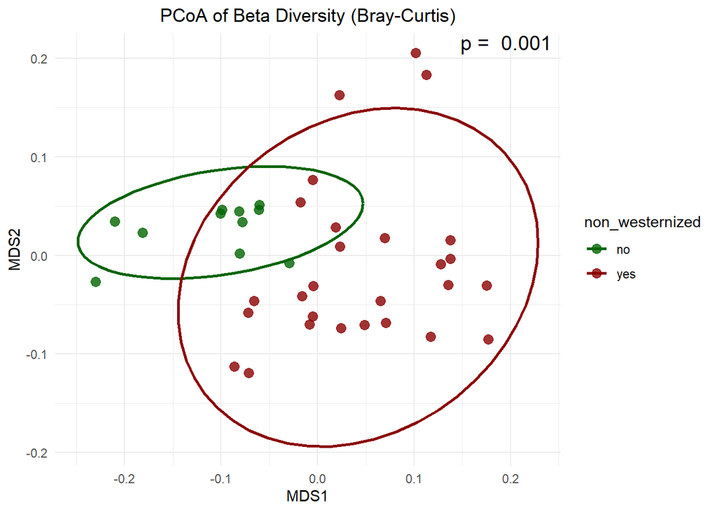

```r
pathwfilt <- pathw[!grepl("\\|", pathw)] # Exclude pathways stratified by species
pathwfilt <- pathwfilt[!grepl("UNMAPPED", pathwfilt)] # Exclude "UNMAPPED"
pathwfilt <- pathwfilt[!grepl("UNINTEGRATED", pathwfilt)] # Exclude "UNINTEGRATED"

# Beta diversity analysis: Bray-Curtis distance calculation
beta_dist <- vegdist(select(dfPW, all_of(pathwfilt)), method = "bray")

# PCoA analysis
pcoa_results <- cmdscale(beta_dist, eig = TRUE, k = 2)  # Perform PCoA with 2 components
pcoa_df <- data.frame(
  MDS1 = pcoa_results$points[, 1],
  MDS2 = pcoa_results$points[, 2],
  non_westernized = dfPW$non_westernized  # Add non_westernized for coloring
)

# Set the order of non_westernized factor
pcoa_df$non_westernized <- factor(pcoa_df$non_westernized, levels = c("no", "yes"))

# Define color palette
colors <- c("no" = "darkgreen", "yes" = "darkred")

# Perform PERMANOVA (adonis2) to compare groups based on Bray-Curtis distance
adonis_results <- adonis2(beta_dist ~ dfPW$non_westernized, permutations = 999)

# PCoA plot with jittered points and p-value
ggplot(pcoa_df, aes(x = MDS1, y = MDS2, color = non_westernized)) +
  geom_point(size = 3, alpha = 0.8) +  # Add points with opacity
  scale_color_manual(values = colors) +
  stat_ellipse(aes(group = non_westernized), level = 0.95, type = "t", size = 1) +  # Add ellipses
  labs(title = "PCoA of Beta Diversity (Bray-Curtis)", x = "MDS1", y = "MDS2") +
  theme_minimal() +
  theme(plot.title = element_text(hjust = 0.5)) +  # Center the title
  annotate("text", x = Inf, y = Inf, label = paste("p = ", round(adonis_results$`Pr(>F)`[1], 3)),
           hjust = 1.1, vjust = 1.1, size = 5, color = "black")  # Add p-value from PERMANOVA
```

## Heatmap for the 30 most abundant pathways

- Let’s do an heatmap that report the 30 most abundant pathways in our set of samples

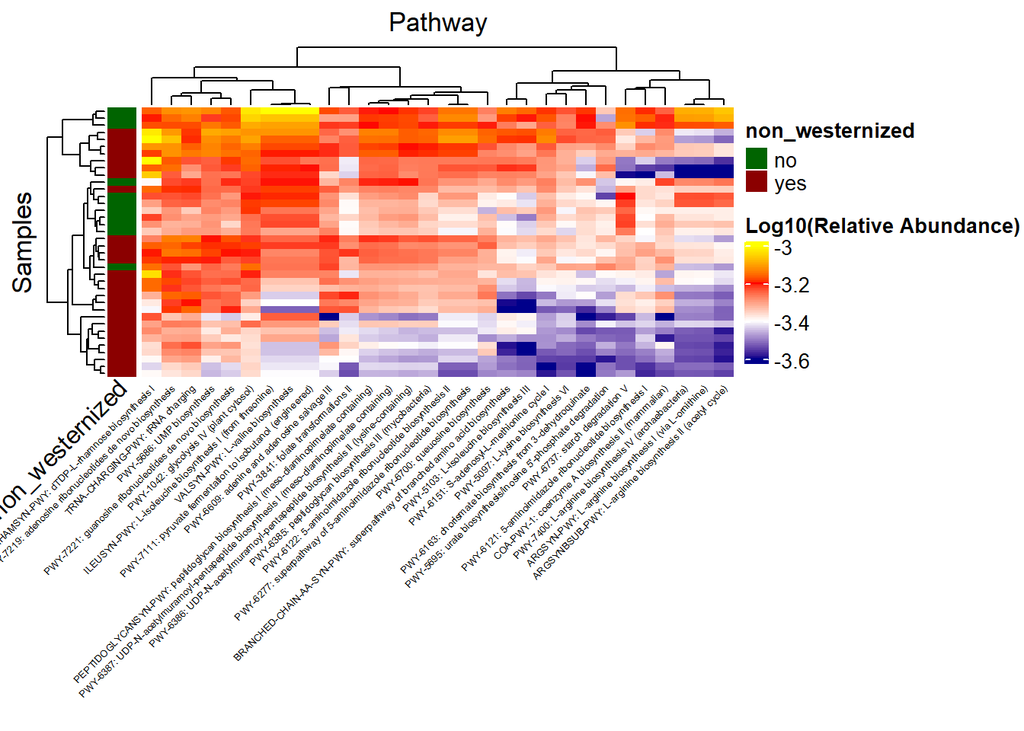

```r
# Compute the total relative abundance for each taxa
sum_pathw <- dfPW %>% select(all_of(pathwfilt)) %>% colSums()

# Select the 30 taxa with the highest sum values
top_30_pathw <- names(sort(sum_pathw, decreasing = TRUE))[1:30]

# Subset the dataframe to include only the top 30 columns
df_top_30 <- dfPW %>% select(all_of(top_30_pathw))

# Apply log10 transformation (add 0.00001 to avoid log(0) issues)
df_top_30_log <- log10(df_top_30 + 0.00001)  # Adding 0.00001 to avoid taking log of 0

# Create a heatmap matrix
df_top_30_log <- as.matrix(df_top_30_log) # Convert the dataframe to matrix for heatmap

# Create a sample annotation for non_westernized
non_westernized_annotation <- rowAnnotation(
  non_westernized = dfPW$non_westernized,
  annotation_name_rot = 45,  # Rotate annotation labels by 45 degrees
  col = list(non_westernized = c("no" = "darkgreen", "yes" = "darkred"))
)

Heatmap(df_top_30_log,
        name = "Log10(Relative Abundance)",  # Heatmap color legend title
        column_title = "Pathway",  # Title for columns
        row_title = "Samples",  # Title for rows
        show_row_names = FALSE,  # Show row names
        show_column_names = TRUE,  # Show column names
        cluster_rows = TRUE,  # Cluster rows
        cluster_columns = TRUE,  # Cluster columns
        col = colorRamp2(c(-3.6, -3.4, -3.2, -3.0), c("darkblue", "white", "red", "yellow")),  # Color scale
        heatmap_legend_param = list(title = "Log10(Relative Abundance)", legend_width = unit(4, "cm")),
        column_names_gp = gpar(fontsize = 5),  # Set font size for column names
        column_names_rot = 45,  # Rotate column names by 45 degrees
        left_annotation = non_westernized_annotation)  # Add non_westernized annotation to the left of the heatmap
```

## Differential abundance analysis: the Wilcoxon rank-sum test

- Let’s do differential abundance analysis on the pathway abundance profiles

```r
# Filter samples by "non_westernized" to include only "no" and "yes"
filtered_dfPW <- dfPW[dfPW$non_westernized %in% c("no", "yes"), ]

# Extract the pathway abundance data (only pathwfilt columns) and remove pathways that are zero across all samples
pathw_data <- filtered_dfPW[, pathwfilt]
non_zero_pathw <- colSums(pathw_data != 0) > 0
pathw_data <- pathw_data[, non_zero_pathw]

# Update the filtered data frame to include only the non-zero taxa
filtered_dfPW <- cbind(filtered_dfPW[, meta], pathw_data)

# Initialize vectors to store p-values, effect sizes, and direction
p_values <- c()
effect_sizes <- c()
directions <- c()

# Perform Wilcoxon rank-sum test, calculate effect size, and determine direction for each taxon
for (pathway in names(pathw_data)) {
  # Create a temporary data frame for the current taxon
  temp_df <- data.frame(
    Abundance = filtered_dfPW[[pathway]],
    non_westernized = filtered_dfPW$non_westernized
  )

  # Perform Wilcoxon rank-sum test
  test_result <- wilcox.test(Abundance ~ non_westernized, data = temp_df)
  p_values[pathway] <- test_result$p.value

  # Calculate effect size for the current taxon using wilcox_effsize
  effect_size_result <- temp_df %>%
    wilcox_effsize(Abundance ~ non_westernized)
  effect_sizes[pathway] <- effect_size_result$effsize

  # Determine the direction of enrichment by comparing group means
  mean_no <- mean(temp_df$Abundance[temp_df$non_westernized == "no"])
  mean_yes <- mean(temp_df$Abundance[temp_df$non_westernized == "yes"])
  if (mean_yes > mean_no) {
    directions[pathway] <- "Enriched in non-westernized"
  } else if (mean_no > mean_yes) {
    directions[pathway] <- "Enriched in westernized"
  } else {
    directions[pathway] <- "No Difference"
  }
}

# Adjust p-values for multiple testing to control for FDR
adjusted_p_values <- p.adjust(p_values, method = "fdr")

# Combine results into a data frame with all taxa, including effect sizes and direction
resultsPW <- data.frame(
  Pathway = names(adjusted_p_values),
  P_Value = p_values,
  Adjusted_P_Value = adjusted_p_values,
  Effect_Size = effect_sizes,
  Direction = directions
)
```

## Differential abundance analysis: barplot with most significant pathways

- Let’s do a barplot that reports the pathways with adjusted p-value < 0.001

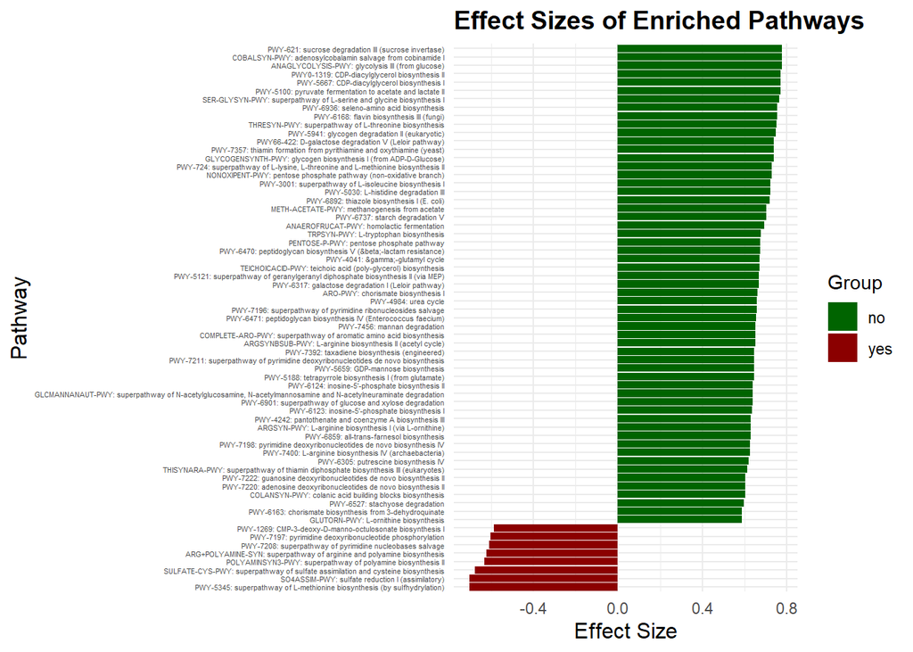

```r
# Filter the results for adjusted p-values < 0.001
filtered_resultsPW <- resultsPW[resultsPW$Adjusted_P_Value < 0.001, ]

# Extract the enriched taxa for Control and CRC groups
enriched_noPW <- filtered_resultsPW[filtered_resultsPW$Direction == "Enriched in westernized", ]
enriched_yesPW <- filtered_resultsPW[filtered_resultsPW$Direction == "Enriched in non-westernized", ]

# Adjust the effect sizes for direction (positive for Control, negative for CRC)
enriched_noPW$Effect_Size <- abs(enriched_noPW$Effect_Size)  # Keep effect size positive for no
enriched_yesPW$Effect_Size <- -abs(enriched_yesPW$Effect_Size)  # Make effect size negative for yes

# Prepare data for plotting
plot_data <- rbind(
  data.frame(Pathway = enriched_noPW$Pathway,
             Effect_Size = enriched_noPW$Effect_Size,
             Group = "no"),
  data.frame(Pathway = enriched_yesPW$Pathway,
             Effect_Size = enriched_yesPW$Effect_Size,
             Group = "yes")
)

# Plot the bar plot
ggplot(plot_data, aes(x = reorder(Pathway, Effect_Size), y = Effect_Size, fill = Group)) +
  geom_bar(stat = "identity") +
  coord_flip() +
  scale_fill_manual(values = c("no" = "darkgreen", "yes" = "darkred")) +
  labs(x = "Pathway", y = "Effect Size", title = "Effect Sizes of Enriched Pathways") +
  theme_minimal() +
  theme(axis.text.y = element_text(size = 4),
        axis.title = element_text(size = 12),
        plot.title = element_text(size = 14, face = "bold"))
```

# Machine learning-based classification for predictive modelling

- We want to assess discrimination between healthy and diseased subjects in a case-control study
- We can consider again the “ZellerG_2024” dataset

```r
# Clear the R environment by removing all existing objects from the workspace.
rm(list = ls())

# Read the relative abundance data from the tabular file "relative_abundances.tsv" into a data frame.
# 'sep = "\t"' specifies tab as the delimiter, 'header = TRUE' indicates that the first row contains column names,
# 'row.names = 1' sets the first column as the row names, and 'check.names = FALSE' prevents R from modifying column names.
abundance_df <- read.table("relative_abundances.tsv", sep = "\t", header = TRUE, row.names = 1, check.names = FALSE)

# Read the metadata from the tabular file "metadata.tsv" into a data frame with the same parameters as above.
metadata_df <- read.table("metadata.tsv", sep = "\t", header = TRUE, row.names = 1, check.names = FALSE)

# Transpose the abundance data frame so that samples become rows and taxa become columns.
abundance_df <- as.data.frame(t(abundance_df))

# Store the column names of the abundance data frame (taxa) and the metadata data frame.
taxa <- colnames(abundance_df)
meta <- colnames(metadata_df)

# Merge the metadata and abundance data frames by row names (sample identifiers).
df <- merge(metadata_df, abundance_df, by = "row.names")

# Set the row names of the merged data frame to the original row names column (sample identifiers).
# Remove the additional Row.names column created during the merge.
row.names(df) <- df$Row.names
df$Row.names <- NULL
```

```r
# Filter samples by "study_condition" to include only "control" and "CRC"
filtered_df <- df[df$study_condition %in% c("control", "CRC"), ]

# Extract the abundance data (only taxa columns) and remove taxa that are zero across all samples
abundance_data <- filtered_df[, taxa]
non_zero_taxa <- colSums(abundance_data != 0) > 0
abundance_data <- abundance_data[, non_zero_taxa]

# Update the filtered data frame to include only the non-zero taxa
filtered_df <- cbind(filtered_df[, meta], abundance_data)
```

```r
# Load necessary libraries
library(caret)
library(pROC)
# Extract features (columns corresponding to 'abundance_data') and label ('study_condition')
features <- filtered_df[, colnames(abundance_data)]
label <- filtered_df$study_condition

# Create a data frame for classification
classification_df <- data.frame(study_condition = label, features)

# Set parameters for 3 runs of cross-validation
set.seed(123)  # For reproducibility
n_runs <- 3  # Number of cross-validation runs
n_folds <- 5  # Number of folds in cross-validation

# Initialize a data frame to store performance metrics
results <- data.frame(Run = integer(), AUC = numeric())

# Perform 3 cross-validation runs
for (i in 1:n_runs) {
  # Set up cross-validation
  cv_control <- trainControl(
    method = "cv",
    number = n_folds,
    classProbs = TRUE,  # Enable class probabilities
    summaryFunction = twoClassSummary  # Use AUC as the metric
  )

  # Ensure binary classification labels are correctly set as factors
  classification_df$study_condition <- factor(classification_df$study_condition)

  # Train the random forest model
  rf_model <- train(
    study_condition ~ .,
    data = classification_df,
    method = "rf",
    trControl = cv_control,
    metric = "ROC",  # Optimize for AUC
    importance = TRUE,
    preProc = c("zv", "center", "scale")  # Pre-processing steps: zero variance, center, scale
  )

  # Store the AUC results from the current run
  results <- rbind(results, data.frame(
    Run = i,
    AUC = mean(rf_model$resample$ROC)  # Average AUC over folds
  ))
}

# Summarize the results
mean_auc <- mean(results$AUC)

cat("Average AUC over", n_runs, "runs:", mean_auc, "\n")
```

```
## Average AUC over 3 runs: 0.852127
```

```r
# Print all run results
print(results)
```

```
##   Run       AUC
## 1   1 0.8562704
## 2   2 0.8584149
## 3   3 0.8416958
```

# Machine learning-based regression for predictive modelling

- We can build predictive models also for estimating continuous variables
- We test the predictability of “age” from the same “ZellerG_2024” dataset

```r
# Extract features (columns corresponding to 'abundance_data') and label ('age')
features <- filtered_df[, colnames(abundance_data)]
label <- filtered_df$age

# Create a data frame for regression
regression_df <- data.frame(age = label, features)

# Set parameters for 3 runs of cross-validation
set.seed(123)  # For reproducibility
n_runs <- 3  # Number of cross-validation runs
n_folds <- 5  # Number of folds in cross-validation

# Initialize a data frame to store performance metrics
results <- data.frame(Run = integer(), RMSE = numeric())

# Perform 3 cross-validation runs
for (i in 1:n_runs) {
  # Set up cross-validation
  cv_control <- trainControl(
    method = "cv",
    number = n_folds,
    summaryFunction = defaultSummary  # Use default regression metrics
  )

  # Train the random forest model
  rf_model <- train(
    age ~ .,
    data = regression_df,
    method = "rf",
    trControl = cv_control,
    metric = "RMSE",  # Optimize for RMSE
    importance = TRUE,
    preProc = c("zv", "center", "scale")  # Pre-processing steps: zero variance, center, scale
  )

  # Store the RMSE results from the current run
  results <- rbind(results, data.frame(
    Run = i,
    RMSE = mean(rf_model$resample$RMSE)  # Average RMSE over folds
  ))
}

# Summarize the results
mean_rmse <- mean(results$RMSE)

cat("Average RMSE over", n_runs, "runs:", mean_rmse, "\n")
```

```
## Average RMSE over 3 runs: 11.4167
```

```r
# Print all run results
print(results)
```

```
##   Run     RMSE
## 1   1 11.37373
## 2   2 11.52888
## 3   3 11.34750
```

```r
# How does this result compare with a naive "prediction" based on simply taking the mean?
sqrt(mean((regression_df$age - mean(regression_df$age)) ^ 2))
```

```
## [1] 11.48547
```